# One Proportion Example

# Problem Statement

The CEO of a large electric utility claims that 80 percent of his 1,000,000 customers are satisfied with the service they receive. To test this claim, the local newspaper surveyed 100 customers, using simple random sampling. 73 were satisfied and the remaining were unsatisfied. Based on these findings from the sample, can we reject the CEO’s hypothesis that 80% of the customers are satisfied? [Tweaked a bit from http://stattrek.com/hypothesis-test/proportion.aspx?Tutorial=AP]

# Competing Hypotheses

## In words

- Null hypothesis: The proportion of all customers of the large electric utility satisfied with service they receive is equal 0.80.
- Alternative hypothesis: The proportion of all customers of the large electric utility satisfied with service they receive is different from 0.80.

## In symbols (with annotations)

- $H_0: \pi = p_{0}$, where $\pi$ represents the proportion of all customers of the large electric utility satisfied with service they receive and $p_0$ is 0.8.
- $H_A: \pi \ne 0.8$

## Set $\alpha$

It’s important to set the significance level before starting the testing using the data. Let’s set the significance level at 5% here.

# Exploring the sample data

```r
elec <- c(rep("satisfied", 73), rep("unsatisfied", 27)) |>
  enframe() |>
  rename(satisfy = value)
```

The bar graph below also shows the distribution of `satisfy`.

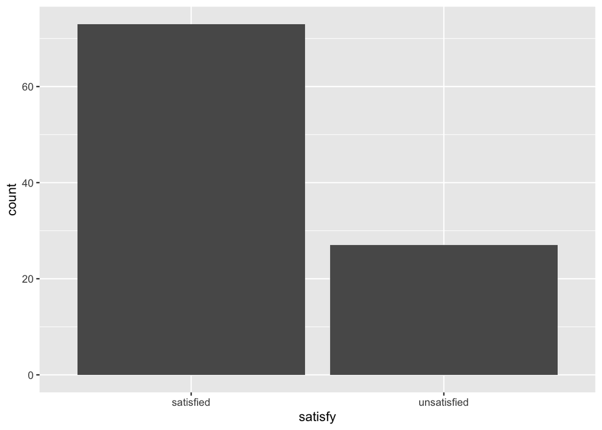

```r
ggplot(data = elec, aes(x = satisfy)) + geom_bar()
```

## Guess about statistical significance

We are looking to see if the sample proportion of 0.73 is statistically different from $p_0 = 0.8$ based on this sample. They seem to be quite close, and our sample size is not huge here ($n = 100$). Let’s guess that we do not have evidence to reject the null hypothesis.

# Non-traditional methods

We’ll use the **`infer`** package to carry out the simulation-based workflow.

## Observed statistic

```r
p_hat <- elec |>
  specify(response = satisfy, success = "satisfied") |>
  calculate(stat = "prop")
p_hat
```

```
## Response: satisfy (factor)
## # A tibble: 1 × 1
##    stat
##   <dbl>
## 1  0.73
```

## Simulation for Hypothesis Test

In order to look to see if 0.73 is statistically different from 0.8, we need to account for the sample size. We also need to determine a process that replicates how the original sample of size 100 was selected. We can use the idea of an unfair coin to *simulate* this process: with `hypothesize(null = "point", p = 0.8)`, `infer` simulates flipping a coin weighted to land “satisfied” 80% of the time, 100 times per replicate, repeating this 10,000 times to build the null distribution of sample proportions.

```r
set.seed(2018)
null_distn_one_prop <- elec |>
  specify(response = satisfy, success = "satisfied") |>
  hypothesize(null = "point", p = 0.8) |>
  generate(reps = 10000) |>
  calculate(stat = "prop")
```

We can next use this distribution to observe our $p$-value. Recall this is a two-tailed test so we will be shading values that are at least as far from 0.8 as our observed 0.73 in BOTH directions:

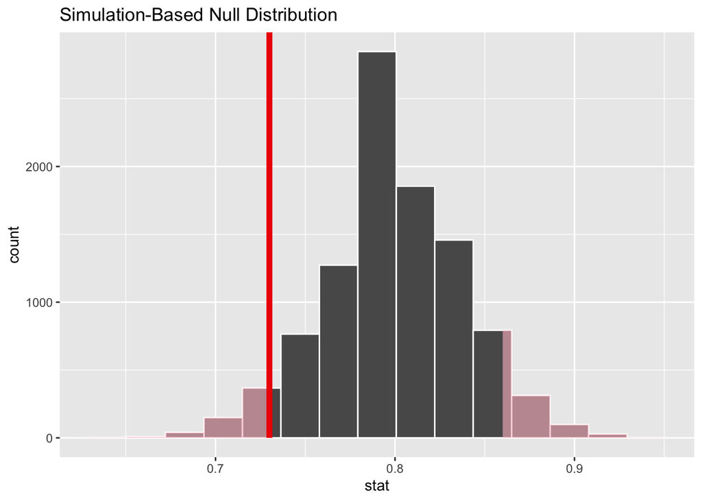

```r
null_distn_one_prop |>
  visualize() +
  shade_p_value(obs_stat = p_hat, direction = "both")
```

### Calculate $p$-value

```r
pvalue <- null_distn_one_prop |>
  get_p_value(obs_stat = p_hat, direction = "both")
pvalue
```

```
## # A tibble: 1 × 1
##   p_value
##     <dbl>
## 1   0.114
```

So our $p$-value is 0.1136 and we fail to reject the null hypothesis at the 5% level.

## Bootstrapping for Confidence Interval

We can also create a confidence interval for the unknown population parameter $\pi$ using our sample data. To do so, we use *bootstrapping*: resample with replacement from our original sample of 100 respondents, compute the proportion of successes each time, and use the 2.5<sup>th</sup> and 97.5<sup>th</sup> percentiles of the resulting distribution for a 95% confidence interval.

```r
boot_distn_one_prop <- elec |>
  specify(response = satisfy, success = "satisfied") |>
  generate(reps = 10000) |>
  calculate(stat = "prop")

ci <- boot_distn_one_prop |>
  get_confidence_interval(level = 0.95)
ci
```

```
## # A tibble: 1 × 2
##   lower_ci upper_ci
##      <dbl>    <dbl>
## 1     0.64     0.81
```

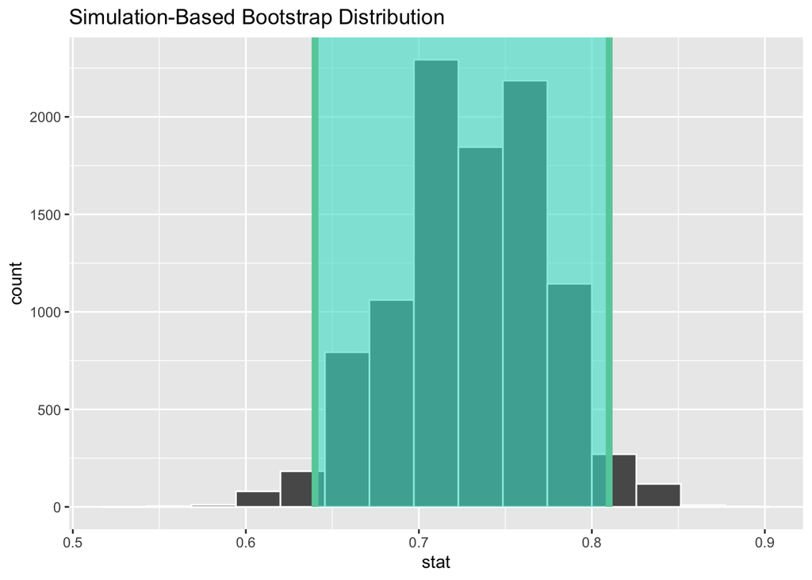

```r
boot_distn_one_prop |>
  visualize() +
  shade_confidence_interval(endpoints = ci)
```

We see that 0.80 is contained in this confidence interval as a plausible value of $\pi$ (the unknown population proportion). This matches with our hypothesis test results of failing to reject the null hypothesis.

**Interpretation**: We are 95% confident the true proportion of customers who are satisfied with the service they receive is between 0.64 and 0.81.

# Traditional methods

## Check conditions

Remember that in order to use the shortcut (formula-based, theoretical) approach, we need to check that some conditions are met.

1. *Independent observations*: The observations are collected independently.

   The cases are selected independently through random sampling so this condition is met.
2. *Approximately normal*: The number of expected successes and expected failures is at least 10.

   This condition is met since 73 and 27 are both greater than 10.

## Test statistic

The test statistic is a random variable based on the sample data. Here, we want to look at a way to estimate the population proportion $\pi$. A good guess is the sample proportion $\hat{P}$. Recall that this sample proportion is actually a random variable that will vary as different samples are (theoretically, would be) collected. We are looking to see how likely is it for us to have observed a sample proportion of $\hat{p}_{obs} = 0.73$ assuming that the population proportion is 0.80 (assuming the null hypothesis is true). If the conditions are met and assuming $H_0$ is true, we can standardize this original test statistic of $\hat{P}$ into a $Z$ statistic that follows a $N(0, 1)$ distribution.

$$Z =\dfrac{ \hat{P} -
p_0}{\sqrt{\dfrac{p_0(1 - p_0)}{n} }} \sim N(0, 1)$$

### Observed test statistic

The observed standardized statistic can be computed directly with `infer` via `calculate(stat = "z")`:

```r
z_hat <- elec |>
  specify(response = satisfy, success = "satisfied") |>
  hypothesize(null = "point", p = 0.8) |>
  calculate(stat = "z")
z_hat
```

```
## Response: satisfy (factor)
## Null Hypothesis: point
## # A tibble: 1 × 1
##    stat
##   <dbl>
## 1 -1.75
```

Our observed sample proportion of 0.73 is about 1.75 standard errors below the hypothesized parameter value of 0.8.

## Compute $p$-value

```r
2 * pnorm(z_hat$stat)
```

```
## [1] 0.080118
```

We can also do this test directly using `infer`’s `prop_test()` wrapper.

```r
elec |>
  prop_test(
    response = satisfy,
    success = "satisfied",
    p = 0.8,
    alternative = "two.sided",
    correct = FALSE,
    z = TRUE
  )
```

```
## # A tibble: 1 × 3
##   statistic p_value alternative
##       <dbl>   <dbl> <chr>
## 1     -1.75  0.0801 two.sided
```

With `z = TRUE`, `prop_test()` reports the same $z$ statistic we computed above, and its $p$-value matches because we are focusing on a two-tailed test. This agrees with the simulation-based result from the non-traditional methods.

## State conclusion

We, therefore, do not have sufficient evidence to reject the null hypothesis. Our initial guess that our observed sample proportion was not statistically different from the hypothesized proportion has not been invalidated. Based on this sample, we do not have evidence that the proportion of all customers of the large electric utility satisfied with service they receive is different from 0.80, at the 5% level.

# Comparing results